# tp1_red_ball_detection-Correction slides

## 1. Introduction au tableau numpy pour le traitement d'image

```python
image_niveau_de_gris = np.array([[8, 9, 10, 11], [5, 3, 2, 1], [8, 9, 0, 0]])
print(image_niveau_de_gris)
```

```
[[ 8  9 10 11]
 [ 5  3  2  1]
 [ 8  9  0  0]]
```

Questions

Quelle est valeur associée au pixel [0, 2] (i.e ligne 0, colonne 2)

```python
image_niveau_de_gris[0, 2]
```

```
10
```

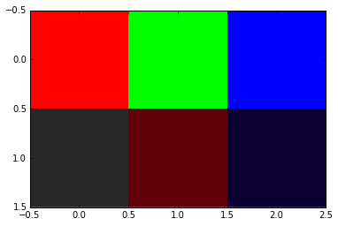

```python
image_rgb = [[[255, 0, 0], [0, 255, 0], [0, 0, 255]], [[40, 40, 40], [100, 0, 10], [10, 0, 50]]]
image_rgb = np.array(image_rgb, dtype=np.uint8)
display_image_color(image_rgb)
```

Questions

Dans l'image *image_rgb* : enlever la composante rouge.

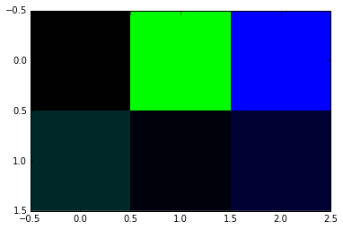

```python
image_rgb[:,:,0] = 0  # enlever le rouge..
display_image_color(image_rgb)
```

# 2. Opérations sur les images:

Dans cette partie nous travaillerons avec l'image de référence *chelsea*.

Vous pouvez néanmoins utiliser l'image que vous souhaitez. Pour charger une image depuis une URL vous pouvez utiliser la fonction imageio.imread.

```
import imageio
souris = imageio.imread('http://static.wamiz.fr/images/animaux/rongeurs/medium/souris.jpg')
display_image_color(souris)
```

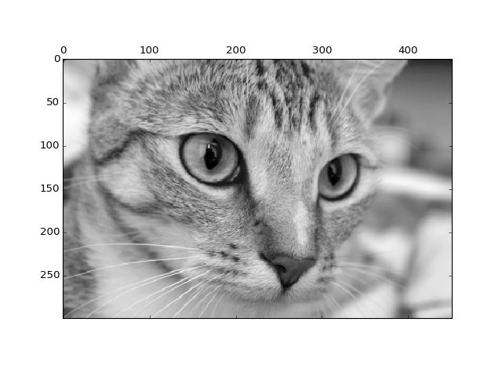

```python
from skimage.data import chelsea
%matplotlib notebook
image = chelsea()
image_nb = skimage.color.rgb2grey(image)
display_image_nb(image_nb)
```

2.1 Opérateurs pixels à pixels

Calculer la moyenne, max, min et somme de l'image

```python
moyenne = np.mean(image_nb)
max, min = np.max(image_nb), np.min(image_nb)
print("La moyenne est {0:0.2f}".format(moyenne))
print("Minimum = {0:0.3f}, maximum = {1:0.3f}".format(min, max))
```

```
La moyenne est 0.46
Minimum = 0.015, maximum = 0.756
```

Donner la dimension de l'image

```python
dimension = np.shape(image_nb)
print("Dimension = {0}".format(dimension))
print("Nombre de lignes {0}, nombre de colones {1}".format(dimension[0], dimension[1]))
```

```
Dimension = (300, 451)
Nombre de lignes 300, nombre de colones 451
```

Créer le mask binaire (i.e une image binaire) qui vaut 1 partout où l'image *image_nb* a une valeur <= 0.4

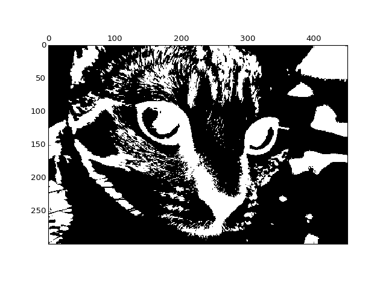

```python
mask = image_nb <= 0.4
display_image_nb(mask)  # blanc == True
```

Créer une nouvelle image *image_nb_thresholded* dans laquelle les pixels du masque sont mis à 0

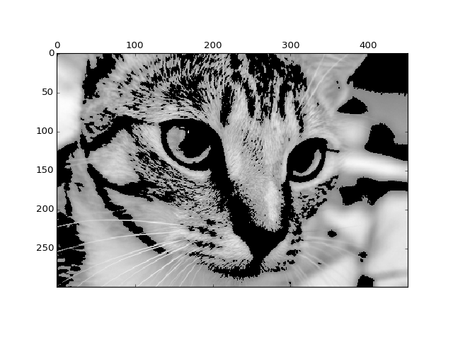

```python
image_nb_thresholded = image_nb.copy()
image_nb_thresholded[mask] = 0
display_image_nb(image_nb_thresholded)
```

Créer et afficher une nouvelle image dans laquelle les pixels de valeurs comprises entre 0.4 et 0.8 sont mis à zéros

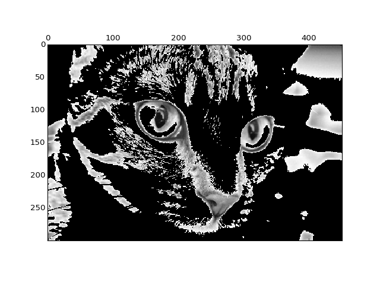

```python
new_image = image_nb.copy()
new_image[(image_nb >= 0.4) & (image_nb <= 0.8)] = 0
display_image_nb(new_image)
```

*Un peu plus compliqué*

- Créer un masque ne correspondant qu'à la partie basse de l'image

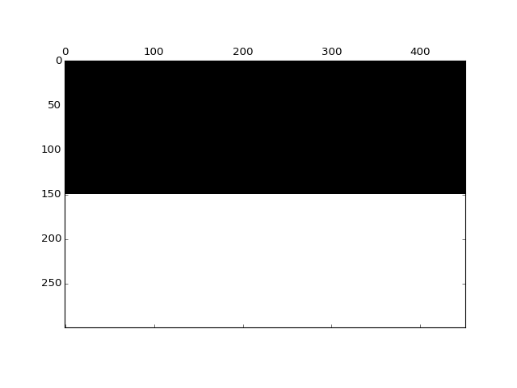

```python
nb_lignes = image_nb.shape[0]
mask = np.zeros(image_nb.shape, dtype=np.bool)
mask[int(nb_lignes/2):, :] = True
display_image_nb(mask)
```

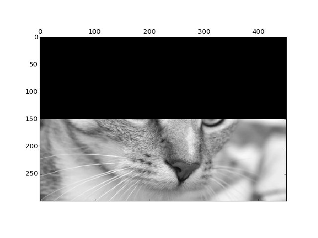

```python
image_partie_basse = image_nb.copy()
image_partie_basse[~mask] = 0  # pour inverser un mask utiliser ~
display_image_nb(image_partie_basse)
```

- L'utiliser pour calculer la moyenne, max, min, et somme

```python
# partie basse :
moyenne_partie_basse = np.mean(image_partie_basse)
max_partie_basse = np.max(image_partie_basse)
min_partie_basse = np.min(image_partie_basse)
somme_partie_basse = np.sum(image_partie_basse)

print("Image partie basse (mean = {:.2f}, max = {:.2f}, min = {:.2f}, somme = {:.2f})".format(moyenne_partie_basse, max_partie_basse,
                                                                              min_partie_basse, somme_partie_basse))
```

```
Image partie basse (mean = 0.24, max = 0.73, min = 0.00, somme = 32421.62)
```

- Inverser la partie basse de l'image

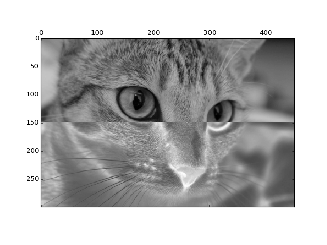

```python
image_avec_partie_basse_inversee = image_nb.copy()
image_avec_partie_basse_inversee[mask] = np.abs(1 - image_nb[mask])
display_image_nb(image_avec_partie_basse_inversee)
```

## 2.2 Filtrage

Filtrer l'image *image_nb* avec les filtres suivants :

- un filtre moyenneur
- un filtre laplacien
- un filtre de Sobel
- utiliser un filtre de canny pour extraire les contours

Les fonctions qui peuvent vous être utiles sont:

```
scipy.ndimage.convolve, skimage.filters.sobel, skimage.feature.canny
```

[figure not shown]

```python
image = skimage.data.camera()
image_nb = skimage.color.rgb2grey(image)
display_image_nb(image_nb)
```

## 2.3 Opérateurs morphologiques

- Effectuer une dilatation et une ouverture morphologiques à l'aide d'un élément structurant de type disk (3,3)
- Effecture une érosion à l'aide d'un élément structurant donné par le tableau suivant :

0 1 0 1 1 1 0 1 0

les fonctions qui peuvent vous être utiles:

```
skimage.morphology.disk, skimage.morphology.opening, skimage.morphology.dilate, skimage.morphology.erosion
```

```python
a = 8
print(a)
for i in range(10):
    print(i)
```

```
8
0
1
2
3
4
5
6
7
8
9
```

## 3. Application

Le but de cette section est de mettre en application les différentes techniques que vous avez vu jusqu'à présent.

Objectif: détecter où se trouve le ballon dans l'image suivante

[figure not shown]

Cette image est extraite du jeu de données disponible sur le site: http://www.iai.uni-bonn.de/~kleind/tracking/index.htm. Nous aurons l'occasion de réutiliser ce type de jeu de données dans les prochains TPs.

Votre objectif

```
- Trouver où se trouve la balle dans l'image
```

Un exemple de résultat:

[figure not shown]

Voici une liste de fonction qui peut vous être utile:

```
 skimage.segmentation.mark_boundaries, skimage.color.rgb2lab, skimage.segmentation.clear_border, skimage.morphology.erosion, dilation, opening, closing, skimage.measure.label, skimage.measure.regionprops
```

C'est parti.

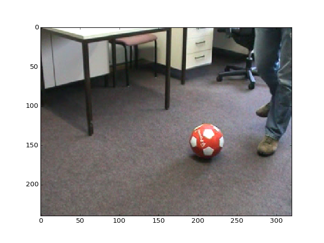

```python
image = imageio.imread('http://srand.fr/red_ball.png')
display_image_color(image)
```

## Bonus:

- Calculer l'histogramme de l'image lena (skimage.data.lena())
- Calculer l'histogramme de l'image chelsea (skimage.data.chelsea())

ressources:

- http://scikit-image.org/docs/dev/auto_examples/plot_windowed_histogram.html

## Bonus bis:

Charger l'image coins (skimage.data.coins())

- Afficher la pièce de la première colonne, dernière ligne.
- Calculer l'histogramme correspondant à cette pièce.
- Calculer l'histogramme normalisé correspondant à cette pièce, et l'afficher à l'aide d'un graphique.